# Add your Name: Riddhi Hindocha

# StudentID: 8978659

# Please submit the notebook and HTML version of your notebook to EConestoga Dropbox

# **Question 1 - Pandas** (12 marks)

- Using RegularSeasonCompactResults.csv
- and Teams.csv

```python
# Using RegularSeasonCompactResults.csv
# 1- Create a filter to show if there are any draw matches
# 2- Apply the filter to the dataframe
# 3- SHOW the dataframe length or count (4 marks)
## TODO: Your code should be here

import pandas as pd

# Load the dataset
df = pd.read_csv("C:/Users/Riddhi/Downloads/Myassignment/data/RegularSeasonCompactResults.csv")

# 1. Create a filter to show if there are any draw matches
draw_filter = (df['Wscore'] == df['Lscore'])

# 2. Apply the filter to the dataframe
draw_matches_df = df[draw_filter]

# 3. Show the dataframe length or count
print("Number of draw matches:", len(draw_matches_df))
```

```
Number of draw matches: 0
```

```python
# Using RegularSeasonCompactResults.csv
# 1- Create a filter showing the entries where the winningteamID= 1400- (last two digits of your id)
# 2- Create another filter for the season of 2013
# 3- Apply the filter to the dataframe
# 4- Show the resulted dataframe (4 marks)
# (Example: IF your id is 8000021, the winning team id = 1400-21= 1389)
# TODO: Your code should be here
import pandas as pd

# Step 1: Load the CSV file into a DataFrame
df = pd.read_csv('C:/Users/Riddhi/Downloads/Myassignment/data/RegularSeasonCompactResults.csv')

# Step 2: Create a filter for the winning team ID (using 1379 as an example)
winning_team_filter = (df['Wteam'] == 1379)

# Step 3: Create a filter for the season of 2013
season_filter = (df['Season'] == 2013)

# Step 4: Apply both filters to the DataFrame
filtered_df = df[winning_team_filter & season_filter]

# Step 5: Show the resulted DataFrame
print(filtered_df)
```

```
        Season  Daynum  Wteam  Wscore  Lteam  Lscore Wloc  Numot
123995    2013       5   1379      67   1443      64    H      1
124191    2013      10   1379      62   1208      60    A      1
124415    2013      14   1379      61   1358      49    A      0
124474    2013      15   1379      69   1414      65    N      0
124526    2013      16   1379      74   1251      56    N      0
124760    2013      22   1379      61   1176      50    H      0
125367    2013      40   1379      93   1212      45    H      0
125464    2013      43   1379      69   1209      67    A      0
125746    2013      53   1379      94   1287      58    A      0
126262    2013      65   1379      75   1349      52    A      0
126455    2013      68   1379      73   1222      54    H      0
126580    2013      72   1379      74   1374      70    A      0
126783    2013      75   1379      74   1412      59    H      0
126905    2013      79   1379     102   1267      46    H      0
127102    2013      82   1379      62   1409      59    A      0
127428    2013      89   1379      79   1412      75    A      0
127872    2013     100   1379      71   1408      60    H      0
128070    2013     103   1379      86   1187      82    A      1
128212    2013     107   1379      45   1431      39    H      0
128695    2013     117   1379      88   1187      69    H      0
128983    2013     124   1379      70   1416      62    H      0
129121    2013     129   1379      81   1412      66    N      0
129166    2013     130   1379      85   1431      67    N      0
```

```python
# Using RegularSeasonCompactResults.csv & Teams.csv
# 1- Load and merge both dataframes
# 2- Where the merge is on WinningTeamId (RegularSeasonCompactResults) and TeamId (Teams.csv)
# 3- Name the dataframe: DFCombined
# 4- Show the top 3 rows (4 marks)
# TODO: Your code should be here

# Load the data frames
import pandas as pd

# Step 1: Load dataframes
df_results = pd.read_csv('C:/Users/Riddhi/Downloads/Myassignment/data/RegularSeasonCompactResults.csv')
df_teams = pd.read_csv('data/Teams.csv')

# Step 2: Merge dataframes on WinningTeamId and TeamId
DFCombined = pd.merge(df_results, df_teams, left_on='Wteam', right_on='Team_Id', how='inner')

# Step 3: Show the top 3 rows of the merged dataframe
print(DFCombined.head(3))
```

```
   Season  Daynum  Wteam  Wscore  Lteam  Lscore Wloc  Numot  Team_Id Team_Name
0    1985      20   1228      81   1328      64    N      0     1228  Illinois
1    1985      25   1228      64   1226      44    N      0     1228  Illinois
2    1985      27   1228      75   1332      72    N      3     1228  Illinois
```

# **Question 2 - Visualizations**

## **Part I**

Using the following dataset: https://raw.githubusercontent.com/mwaskom/seaborn-data/master/penguins.csv choose the most convenient graph to show the following, each question in **one** graph, using the library of your choice: (18 Marks)

**1. The relationship between the penguin's bill length and bill depth for each species.** (5 marks)

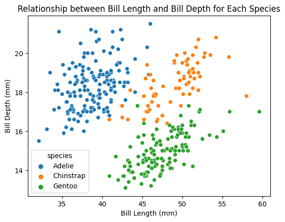

```python
## TODO: Check your attributes, make a graph using Matplotlib or Seaborn to show the relationship needed

import pandas as pd
import seaborn as sns
import matplotlib.pyplot as plt

# Assuming you have a DataFrame named 'penguins_df'
# Replace 'penguins.csv' with your actual datasetC:/Users/Riddhi/Downloads/Myassignment/data/
penguins_df = pd.read_csv('C:/Users/Riddhi/Downloads/Myassignment/data/penguins.csv')

# Plotting the relationship using Seaborn
sns.scatterplot(x='bill_length_mm', y='bill_depth_mm', hue='species', data=penguins_df)
plt.title("Relationship between Bill Length and Bill Depth for Each Species")
plt.xlabel("Bill Length (mm)")
plt.ylabel("Bill Depth (mm)")
plt.show()
```

**What do you observe from the graph?** (2 marks)

The plot graph shows three unique clusters, each representing a different penguin species: Adelie, Chinstrap, and Gentoo. The length and depth of penguin bills vary between species. Adelie penguins' bills vary greatly in length and depth.

Gentoo penguins have a large variety of bill lengths but a restricted range of bill depths.

**Why did you choose this type of graph?** (2 marks)

- The scatter plot was chosen for its capacity to illustrate the relationship between two continuous variables as well as visually differentiate various groups (penguin species) depending on color, which aids in pattern and trend analysis. Three reasons for selecting this graph: Relationship visualization, species differentiation, and cluster identification

**2. Suitable graph of the mean BMI (BMI not body_mass weight_in_kg/height(m2)) of female and male penguins. (Assume the height is the flipper length)** (5 marks)

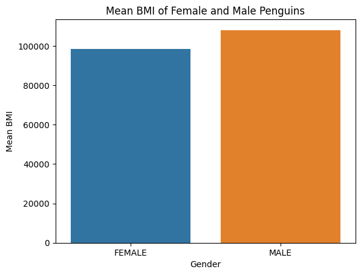

```python
#Your answer here
import pandas as pd
import seaborn as sns
import matplotlib.pyplot as plt

# Assuming you have a DataFrame named 'penguins_df'
# Replace 'penguins.csv' with your actual dataset
penguins_df = pd.read_csv('C:/Users/Riddhi/Downloads/Myassignment/data/penguins.csv')

# Calculate BMI for each penguin
penguins_df['BMI'] = penguins_df['body_mass_g'] / ((penguins_df['flipper_length_mm'] / 1000) ** 2)

# Group by gender and calculate mean BMI
mean_bmi_by_gender = penguins_df.groupby('sex')['BMI'].mean().reset_index()

# Plotting the mean BMI for female and male penguins
sns.barplot(x='sex', y='BMI', data=mean_bmi_by_gender)
plt.title("Mean BMI of Female and Male Penguins")
plt.xlabel("Gender")
plt.ylabel("Mean BMI")
plt.show()
```

## What do you observe from the graph?** (2 marks)

- Observations from the graph

  Mean BMI Comparison

  Difference or Similarity

  Visualizing Trends

## Why did you choose this type of graph?** (2 marks)

Reasons for selecting the graph:

Comparison of categorical data

Visual Clarity

Simple and informative.

## **Part II**

You can find the csv file that contains the museum visitors data here: ./CSVs/museum_visitors.csv (8 marks)

Review the data by taking a look at a few of the rows.

```python
# Your solution here
import pandas as pd

# Load the museum visitors data
file_path = "C:/Users/Riddhi/Downloads/Myassignment/data/museum_visitors.csv"
museum_df = pd.read_csv(file_path)

# Display a few rows of the dataset
print(museum_df.head())
```

```
         Date  Avila Adobe  Firehouse Museum  Chinese American Museum
0  2014-01-01        24778              4486                     1581  \
1  2014-02-01        18976              4172                     1785
2  2014-03-01        25231              7082                     3229
3  2014-04-01        26989              6756                     2129
4  2014-05-01        36883             10858                     3676

   America Tropical Interpretive Center
0                                  6602
1                                  5029
2                                  8129
3                                  2824
4                                 10694
```

Convince the museum board

The Firehouse Museum claims they ran an event in 2014 that brought an incredible number of visitors, and that they should get extra budget to run a similar event again. The other museums think these types of events aren't that important, and budgets should be split purely based on recent visitors on an average day.

To show the museum board how the event compared to regular traffic at each museum, create a suitable chart that shows how the number of visitors to each museum evolved over time. (4 marks)

```
         Date  Avila Adobe  Firehouse Museum  Chinese American Museum
0  2014-01-01        24778              4486                     1581  \
1  2014-02-01        18976              4172                     1785
2  2014-03-01        25231              7082                     3229
3  2014-04-01        26989              6756                     2129
4  2014-05-01        36883             10858                     3676

   America Tropical Interpretive Center
0                                  6602
1                                  5029
2                                  8129
3                                  2824
4                                 10694
```

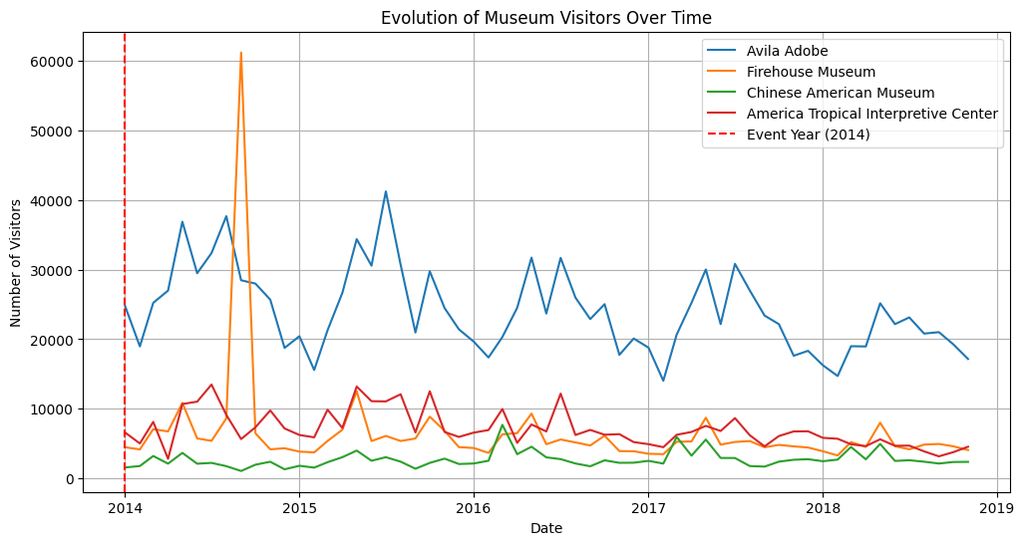

```python
#Your solution here
#Your solution here

import pandas as pd
import matplotlib.pyplot as plt

# Load the museum visitors data
file_path = "C:/Users/Riddhi/Downloads/Myassignment/data/museum_visitors.csv"
museum_df = pd.read_csv(file_path)

# Check the structure of the dataset
print(museum_df.head())

# Convert the 'Date' column to datetime format
museum_df['Date'] = pd.to_datetime(museum_df['Date'])

# Create a line chart to show the evolution of visitors over time for each museum
plt.figure(figsize=(12, 6))

# Iterate through each museum and plot the number of visitors over time
for museum in museum_df.columns[1:]:
    plt.plot(museum_df['Date'], museum_df[museum], label=museum)

# Highlight the year 2014 for emphasis on the event
plt.axvline(pd.to_datetime('2014-01-01'), color='red', linestyle='--', label='Event Year (2014)')

# Set plot title and labels
plt.title('Evolution of Museum Visitors Over Time')
plt.xlabel('Date')
plt.ylabel('Number of Visitors')
plt.legend()
plt.grid(True)

# Show the plot
plt.show()
```

## What did you observe from the graph? (2 marks)

Observations of the code:

Trends over time, impact of the 2014 event, comparisons between museums, seasonal patterns.

## Why did you choose this type of graph? (2 marks)

*The line chart was chosen for its ability to exhibit time-series data, facilitate comparisons between museums, and efficiently convey information about the change of visitor numbers over time, including the year of interest.

## **PART III**

Using the file in ./CSVs/gas_prices.csv  
Use a suitable plot/graph that will show the relationship between the gas price for each country (vs others) over all years. (8 marks)

First, review the data by taking a look at a few of the rows.

```python
# Your solution hereC:/Users/Riddhi/Downloads/Myassignment/data/gas_prices.csv
gasprices_data = pd.read_csv('C:/Users/Riddhi/Downloads/Myassignment/data/gas_prices.csv')
print(gasprices_data.head())
```

```
   Year  Australia  Canada  France  Germany  Italy  Japan  Mexico
0  1990        NaN    1.87    3.63     2.65   4.59   3.16    1.00  \
1  1991       1.96    1.92    3.45     2.90   4.50   3.46    1.30
2  1992       1.89    1.73    3.56     3.27   4.53   3.58    1.50
3  1993       1.73    1.57    3.41     3.07   3.68   4.16    1.56
4  1994       1.84    1.45    3.59     3.52   3.70   4.36    1.48

   South Korea    UK   USA
0         2.05  2.82  1.16
1         2.49  3.01  1.14
2         2.65  3.06  1.13
3         2.88  2.84  1.11
4         2.87  2.99  1.11
```

Then Plot using the most suitable plot on your opinion (5 marks)

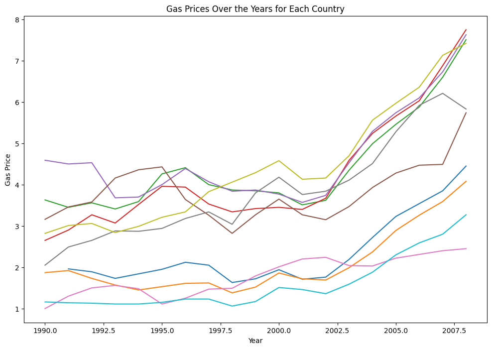

```python
## Your solution here

# Plotting the gas prices for each country over all years
plt.figure(figsize=(12, 8))
sns.lineplot(x='Year', y='Australia', data=gasprices_data)
sns.lineplot(x='Year', y='Canada', data=gasprices_data)
sns.lineplot(x='Year', y='France', data=gasprices_data)
sns.lineplot(x='Year', y='Germany', data=gasprices_data)
sns.lineplot(x='Year', y='Italy', data=gasprices_data)
sns.lineplot(x='Year', y='Japan', data=gasprices_data)
sns.lineplot(x='Year', y='Mexico', data=gasprices_data)
sns.lineplot(x='Year', y='South Korea', data=gasprices_data)
sns.lineplot(x='Year', y='UK', data=gasprices_data)
sns.lineplot(x='Year', y='USA', data=gasprices_data)
plt.title('Gas Prices Over the Years for Each Country')
plt.xlabel('Year')
plt.ylabel('Gas Price')
plt.show()
```